# Varience in Hotel Arrival Times

Titus

`8/25/2022`

The data comes from a data package that I worked with during my coursework related to the Google Data Anlytics Certificate on Coursera.

If you would like to download the data you can find it here.

```r
library(ggplot2)
library(tidyverse)
```

### Project Data Frames

```r
hotel_bookings <- read.csv('./hotel_bookings_copy.csv')

filtered_2017 <- hotel_bookings %>%
  filter(hotel_bookings$arrival_date_year=='2017')

filtered_2015 <- hotel_bookings %>%
  filter(hotel_bookings$arrival_date_year=='2015')

filtered_2016 <- hotel_bookings %>%
  filter(hotel_bookings$arrival_date_year=='2016')
```

# **Objective: Variance in Hotel Arrival Time**

In this analysis I will be exploring the variance in hotel booking activity as it relates to number of arrivals throughout a given year categorized by month. By examining these graphs it would give insight into yearly booking and arrival trends.

#### We will be using hotel data (hotel_bookings) to build a bar chart

Below is a version displaying an overall summary of 2015-2017

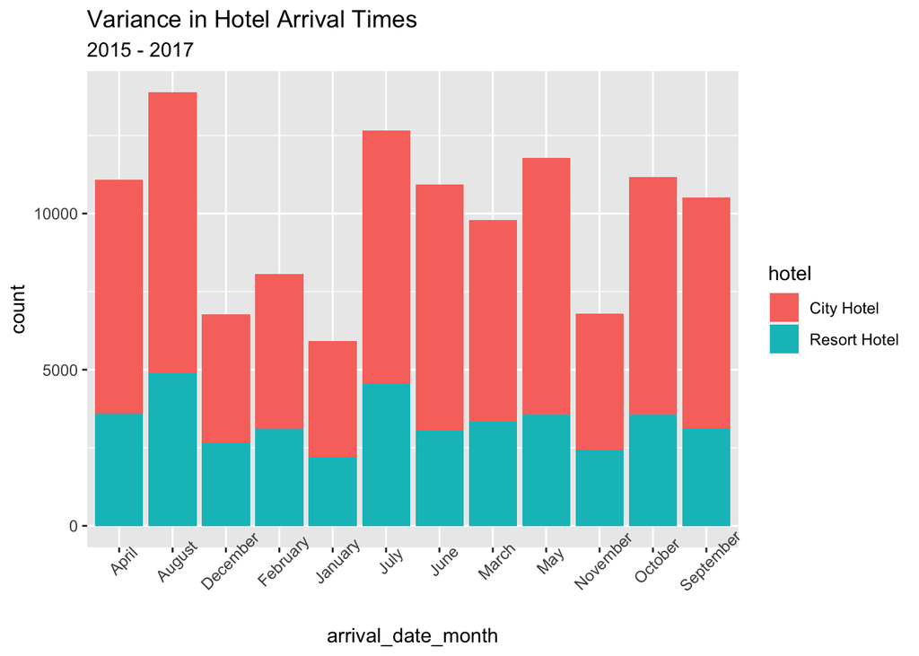

```r
ggplot(data=hotel_bookings) +
  geom_bar(mapping=aes(x=arrival_date_month,fill=hotel))+
  labs(title='Variance in Hotel Arrival Times',
       subtitle='2015 - 2017')+
  theme(axis.text.x=element_text(angle=45))
```

We now create values for each new plot based on the data frames we created above.

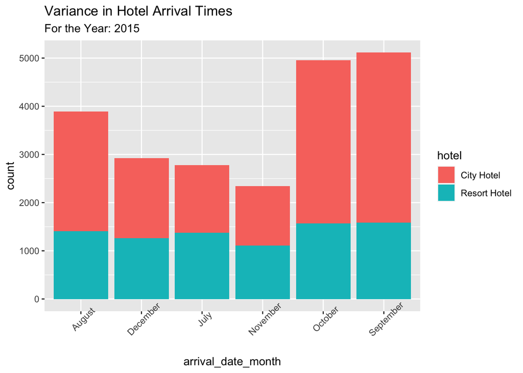

```r
ggplot(data=filtered_2015) +
  geom_bar(mapping=aes(x=arrival_date_month,fill=hotel))+
  labs(title='Variance in Hotel Arrival Times',
       subtitle='For the Year: 2015')+
  theme(axis.text.x=element_text(angle=45))
```

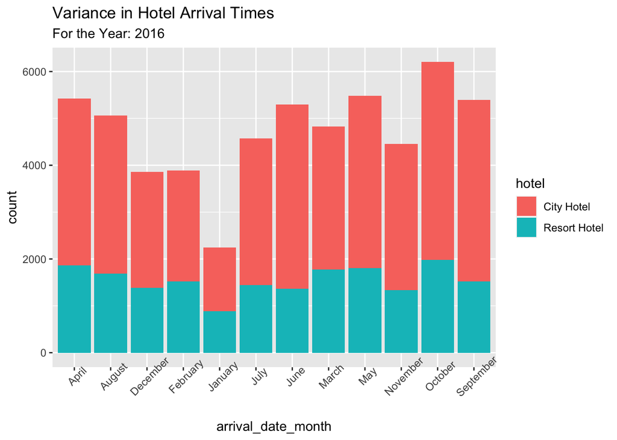

```r
ggplot(data=filtered_2016) +
  geom_bar(mapping=aes(x=arrival_date_month,fill=hotel))+
  labs(title='Variance in Hotel Arrival Times',
       subtitle='For the Year: 2016')+
  theme(axis.text.x=element_text(angle=45))
```

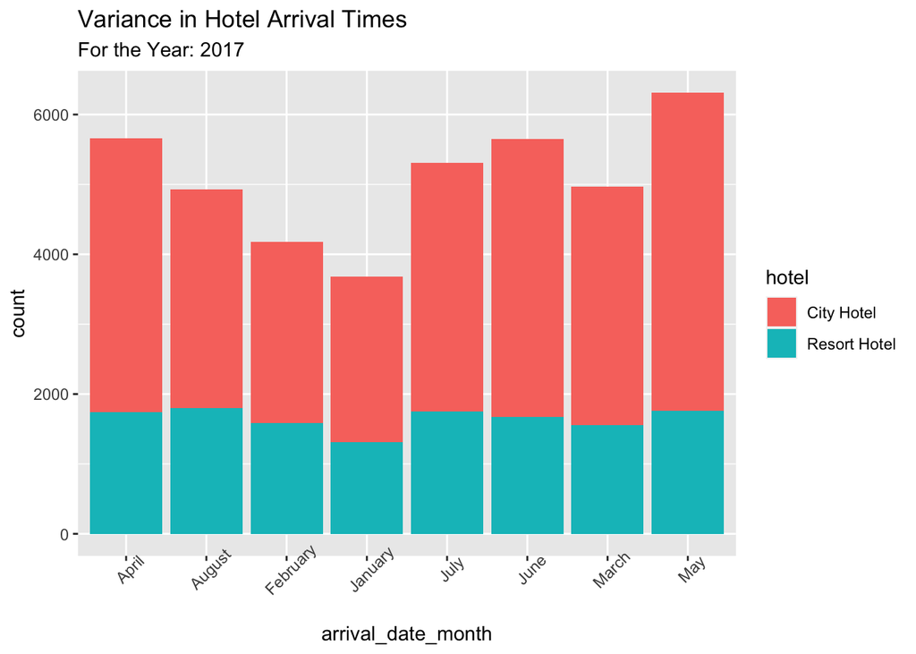

```r
ggplot(data=filtered_2017) +
  geom_bar(mapping=aes(x=arrival_date_month,fill=hotel))+
  labs(title='Variance in Hotel Arrival Times',
       subtitle='For the Year: 2017')+
  theme(axis.text.x=element_text(angle=45))
```

### Results

Compared to 2016, which had data reported throughout the entire year, 2017 and 2015 had an insufficient amount of data to give a holistic picture of trends. As a result, 2016 was the only year that provided helpful analysis at the overview of a year, but monthly comparisons of August and July (the only months shared across all three years) would be also be a useful point of further examination.